# Weekly Energy Charts

January 06, 2023

Sign up to receive our email updates via [Substack](https://leach.substack.com/)

[interactive chart not shown]

# Featured Stories

## Commit to coal, says “reliable” source

#### [Marc Vermette](https://www.linkedin.com/in/marc-vermette/)

Fix and modernize South Africa’s existing coal power plants as a cheap and easy way to achieve a reasonable price of electricity, says [Andrey Melnichenko](https://www.aa.com.tr/en/energy/coal/russian-billionaire-resigns-from-biggest-coal-company-after-eu-sanctions-/34824), a sanctioned Russian coal industry billionaire.

Currently, [South Africa uses coal](https://www.energy.gov.za/files/coal_frame.html#:~:text=South%20Africa%27s%20indigenous%20energy%20resource,needs%20are%20provided%20by%20coal.) to generate 80% of its electricity.

Energy generation of South Africa’s primary and state power utility, Eskom

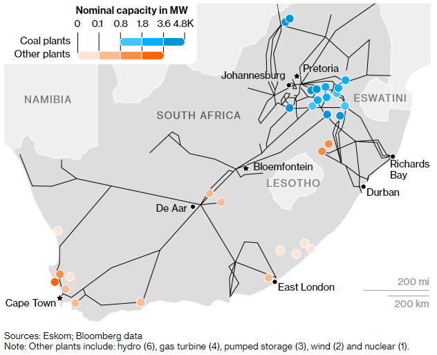

South Africa has experienced more than [200 days of power cuts this year](https://www.africanews.com/2022/12/29/sa-power-cuts-force-companies-to-scale-back//#:~:text=2022%20has%20been%20one%20of,power%20cuts%20are%20slowly%20resuming.), each lasting about six hours per day, contributing to a lack of economic growth and political stress.

The state power utility claims they require $4.2 billion USD over the next 5 years to be able to expand their power grid, with additional funding needed for clean energy capacity.

With the falling costs of renewables, it is my hope that a more [obvious solution](https://theconversation.com/south-africa-could-produce-a-lot-more-renewable-energy-heres-what-it-needs-185897) than [committing to coal](https://www.bbc.com/news/world-africa-63513278) will be adopted by South Africa’s decision makers.

[Original Article](https://www.bloomberg.com/news/articles/2022-12-30/south-africa-s-power-grid-is-too-weak-for-green-energy-billionaire-says)

## A just transition?

#### [Marc Vermette](https://www.linkedin.com/in/marc-vermette/)

Alberta’s premier, Danielle Smith, [criticized](https://twitter.com/ABDanielleSmith/status/1611119725135757317) the [federal government’s intentions](https://www.rncanengagenrcan.ca/en/collections/just-transition) regarding the continued transition towards renewable energy.

She called the plans [“ill-conceived, “short-sighted,” and “detrimental to Canada’s economic recovery.”](https://twitter.com/ABDanielleSmith/status/1610418366145253377)

However, Jonathan Wilkinson, the Canadian Minister of Natural Resources, claims recent efforts “[encourage] sustainable job creation and economic growth in every region of the country.”

Wilkinson is not concerned that energy workers will be out of jobs and instead asserts that he is more concerned that there will not be enough people to fill the jobs created by new opportunities in Canadian renewable energy.

You would have seen that Andrew Leach (pretty sure you know him) highlighted the flaws in Alberta’s recent decision to decline to participate in the “regional energy resource tables” led by the federal government, emphasizing the importance of government involvement throughout an energy transition, especially in Alberta. Rumour has it Leach will have a piece out next week with more details.

[Read more here](https://www.cbc.ca/news/canada/calgary/federal-legislation-net-zero-1.6702333)

## Tesla hit with high lithium prices

#### [Erica Beattie](https://www.linkedin.com/in/erica-beattie-594b471a1/?originalSubdomain=ca)

An [article from Bloomberg](https://www.bloomberg.com/news/articles/2023-01-03/tesla-faces-higher-lithium-prices-after-supplier-amends-deal) states that Tesla’s supplier of the lithium that powers their vehicles, Piedmont Lithium Inc., amended their agreement with the EV giant. Now, Piedmont will supply 125,000 metric tons of lithium concentrate to Tesla starting in the second half of 2023 through to the end of 2025. Prior agreements had prices locked in, but this current deal includes variable pricing based on market prices. This is a significant change for Tesla.

Given Tesla’s market power as the biggest buyer in its sector, they have been able to dictate agreement terms, resulting in long-term supply deals at fixed prices. This is changing as prices of key battery materials, such as lithium, are rising relentlessly, to over 1,200% above recent years’ prices, as supply struggles to meet increasing demand. Because of this, manufacturers have had to raise their prices. Just this past year, the average price for a lithium-ion battery pack increased by 7%. Two years ago, the initial agreement between Tesla and Piedmont was announced, and lithium prices were at an all-time low because of the pandemic. Some are predicting that this new supply agreement with Tesla will “deliver highly attractive margins” for Piedmont.

[Another article posted on Bloomberg at the end of 2022 has more details on the matter](https://www.bloomberg.com/news/articles/2022-11-29/tesla-tsla-lithium-mine-strategy-tested-by-ford-gm#xj4y7vzkg).

[figure not shown]

Soaring Lithium Prices

## Coal Demand Increasing Worldwide

#### [Yousaff Habib](https://www.linkedin.com/in/yousaff-habib-6684891a5/)

Erica wrote last week about Germany’s increasing use of coal in the face of its current energy crisis, but recent data suggests this trend is not confined to Germany. Global coal use is set to rise by 1.2% in 2022, reaching 8 billion tonnes for the first time and surpassing the previous record set in 2013, according to the International Energy Agency’s (IEA) annual market report on the sector. While coal consumption is expected to remain flat through 2025 due to strong demand in emerging Asian economies, it is anticipated to fall in advanced economies as renewables replace it for electricity generation. The IEA’s report also noted that there is no sign of surging investment in export-driven coal projects, reflecting caution among investors and mining companies about the medium and long-term prospects for coal. Despite this, the world’s three largest coal producers – China, India and Indonesia – are all expected to hit production records in 2022. Moreover, coal prices have surged due to the aforementioned energy crisis as well as adverse weather conditions in Australia, which is a major supplier. The IEA produced a special report detailing what could be done to reduce coal use and meet international climate goals, which can be found [here](https://www.iea.org/news/achieving-a-swift-reduction-in-global-coal-emissions-is-the-central-challenge-for-reaching-international-climate-targets).

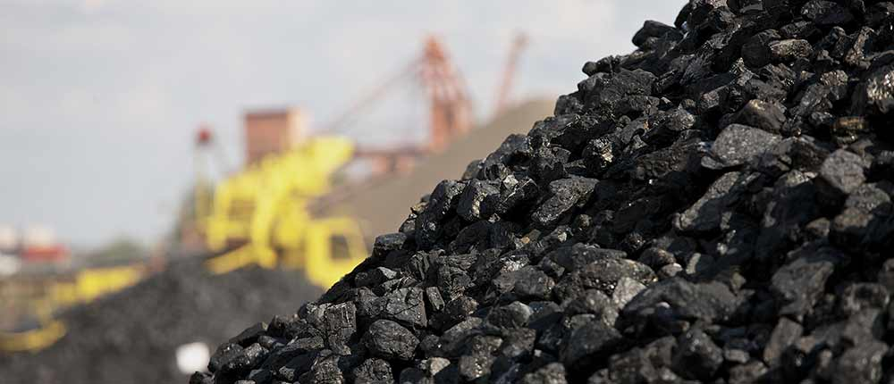

# Oil

## Weekly Crude Prices

### Feature Crude

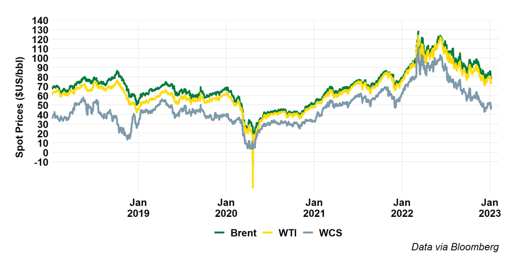

### Alberta Crude

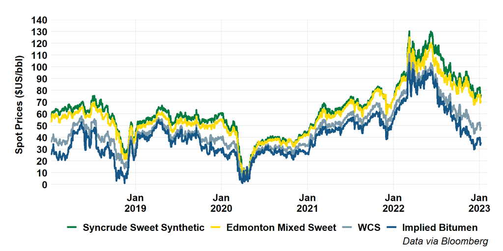

### Alberta Crude (Short)

[figure not shown]

### US Crude

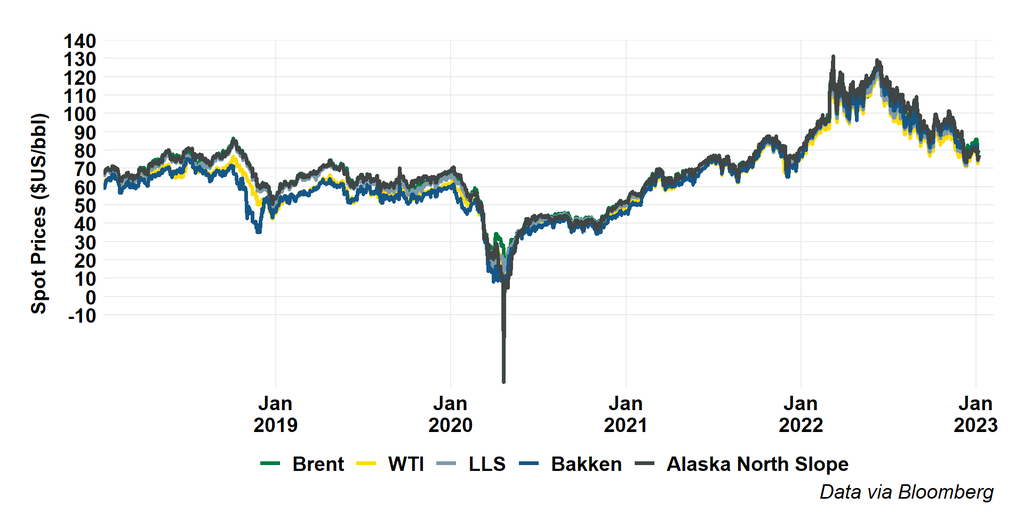

### Global Crude

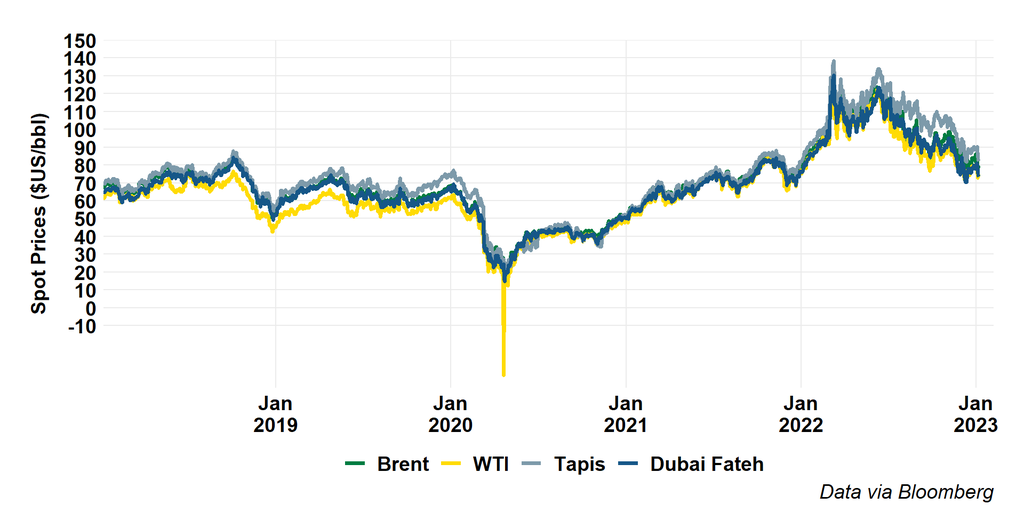

## Oil Price Differentials

### Brent-WTI

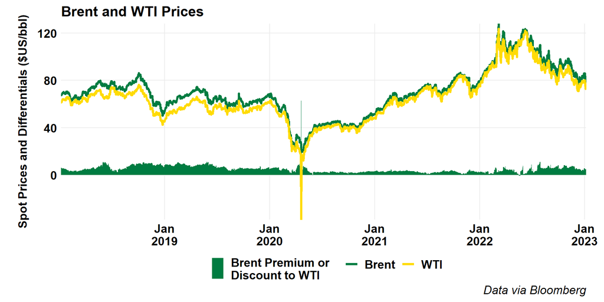

### WTI-WCS

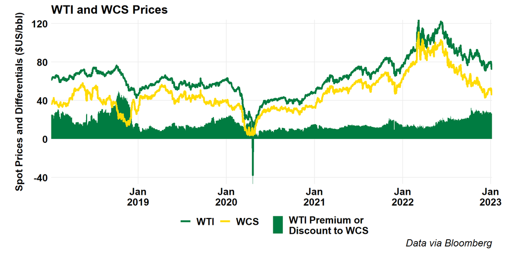

### WTI-WCS (Short)

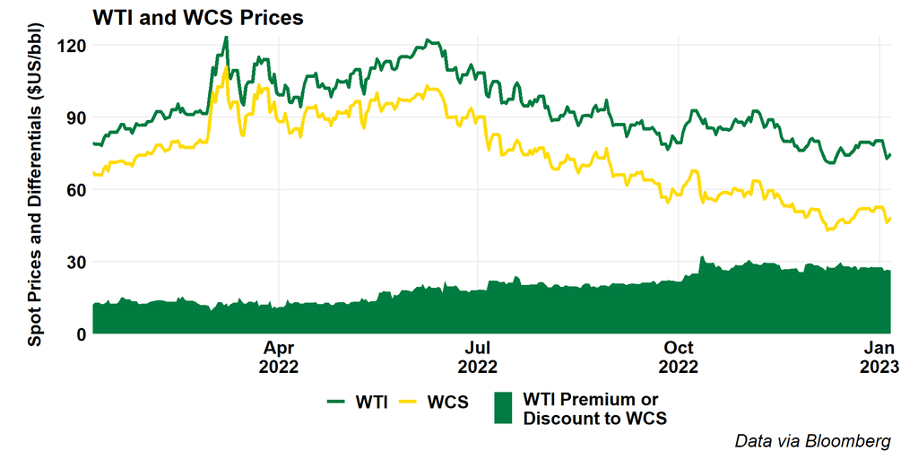

### Maya-WCS

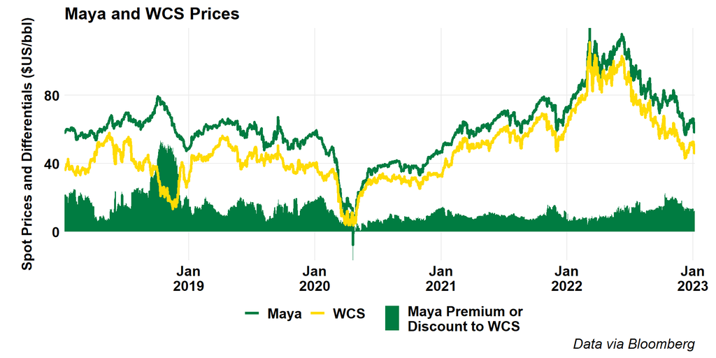

### WTI Cushing vs MEH

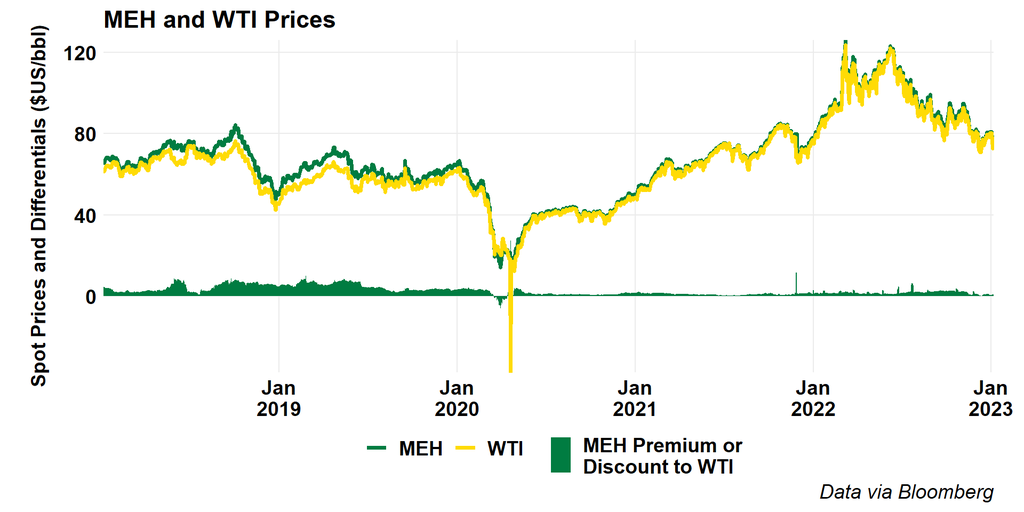

## Forward Curves

### WTI

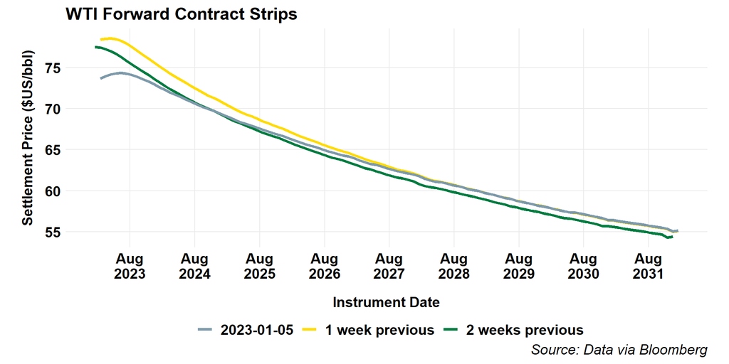

### Brent

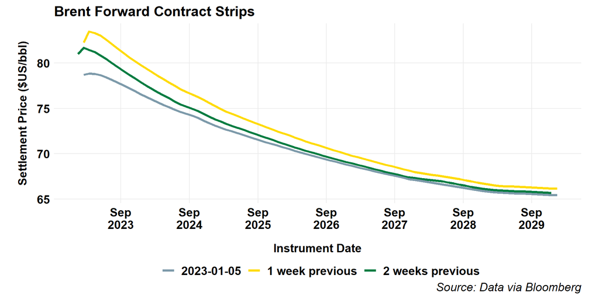

## Canadian Crude Supply and Disposition

### Canadian Production

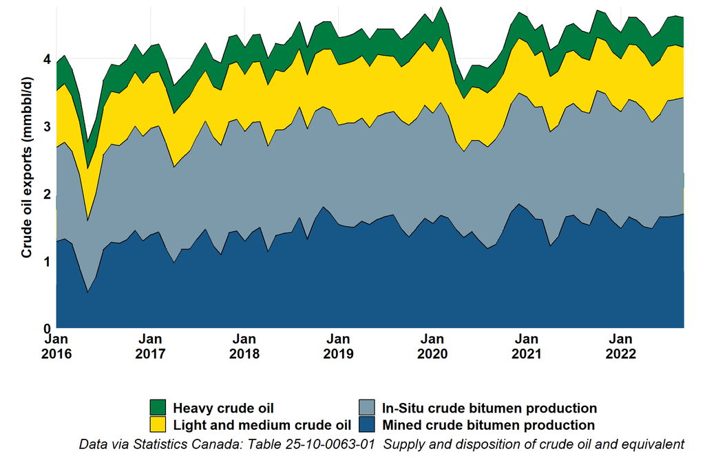

### Alberta Production

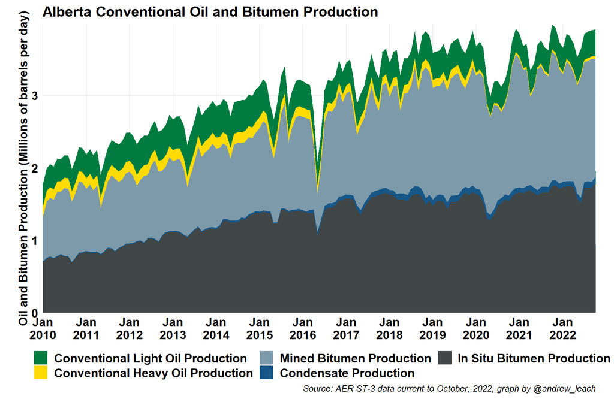

### Imports

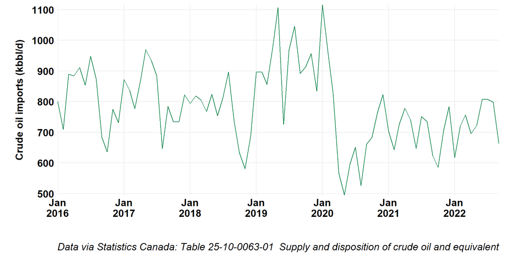

### Exports

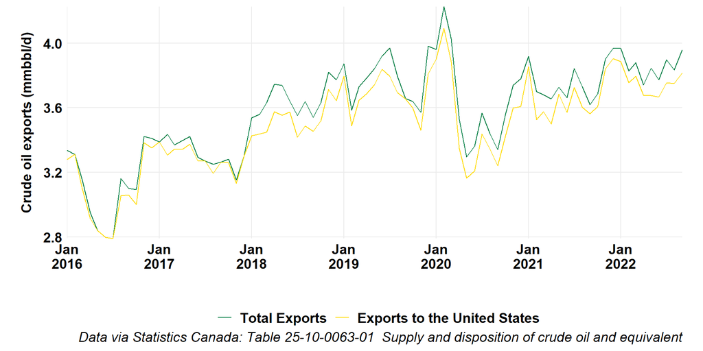

### Exports by Rail

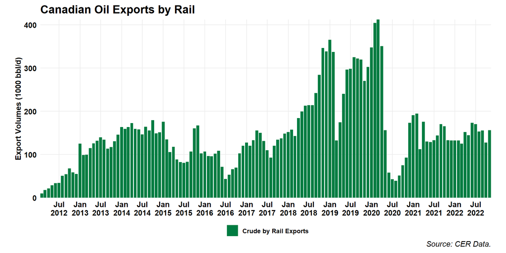

## US Oil

### Production

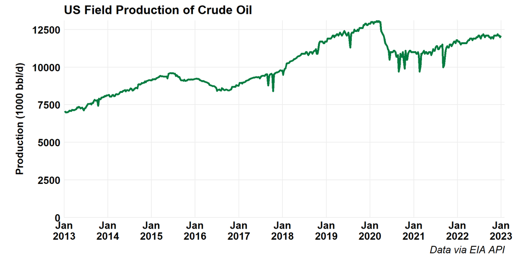

### LTO Production by Play

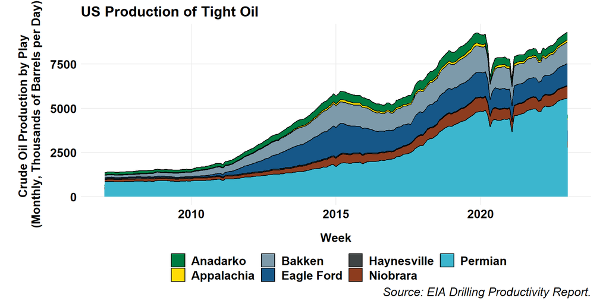

### Net Imports

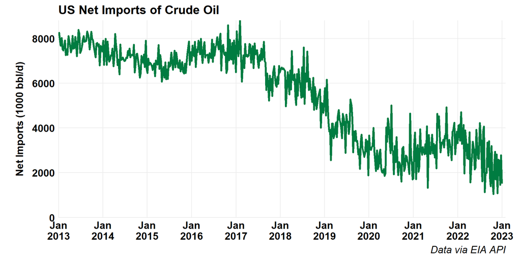

### Oil and Product Net Imports

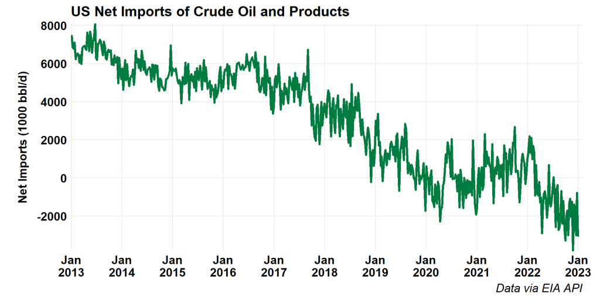

### Inventories

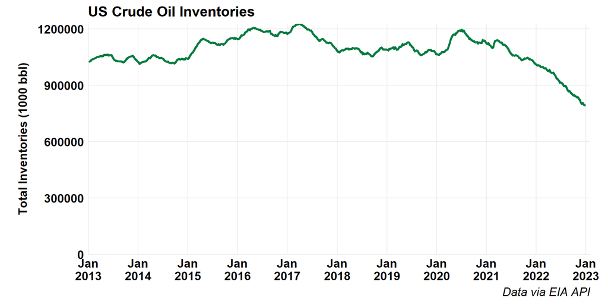

### EIA STEO Forecasts

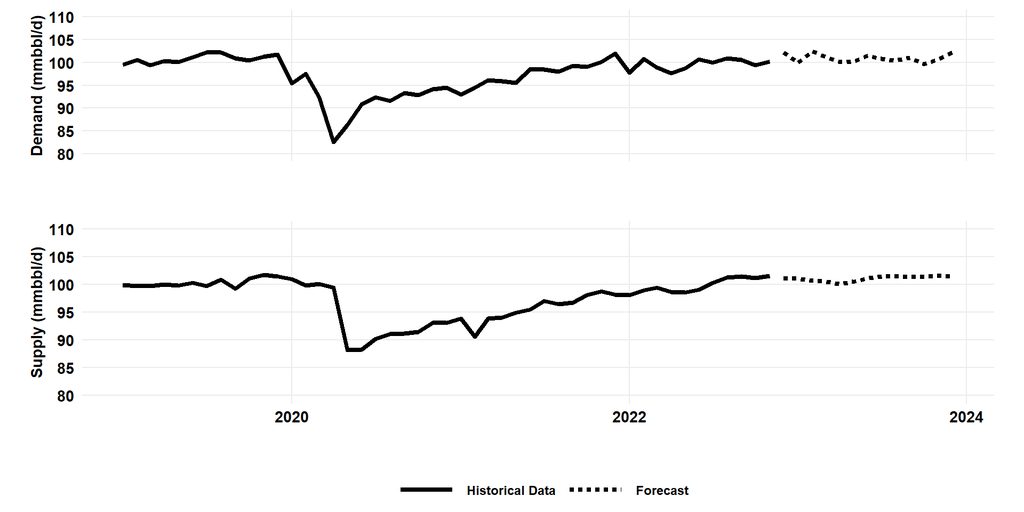

# Refined Products

## Canadian Gasoline Prices

### Map

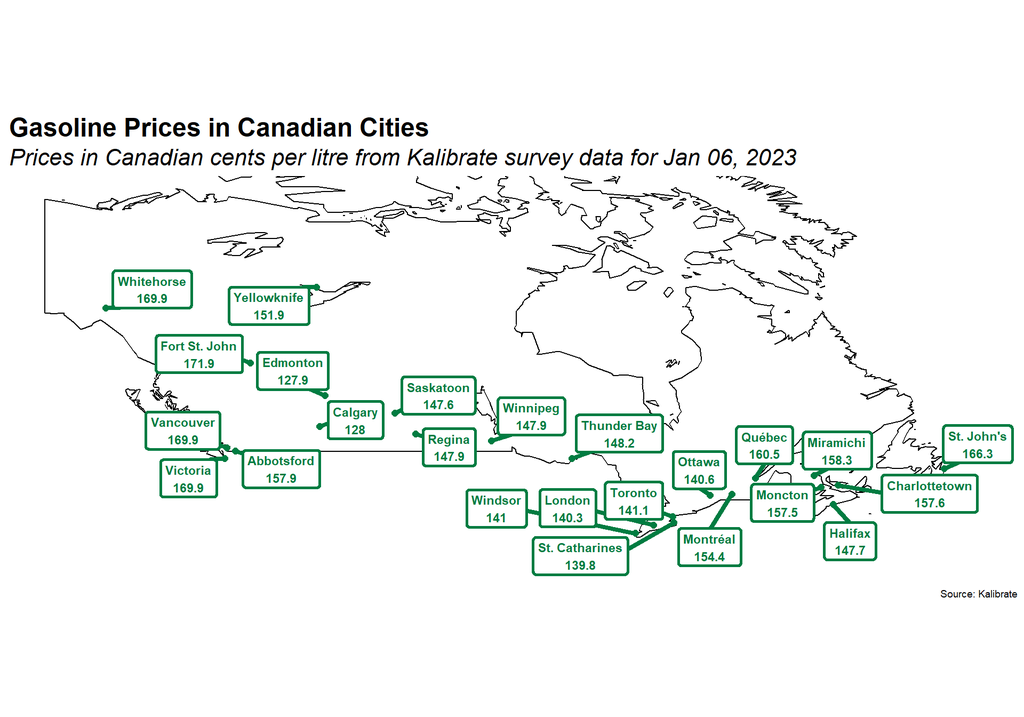

### Historic Gasoline Prices

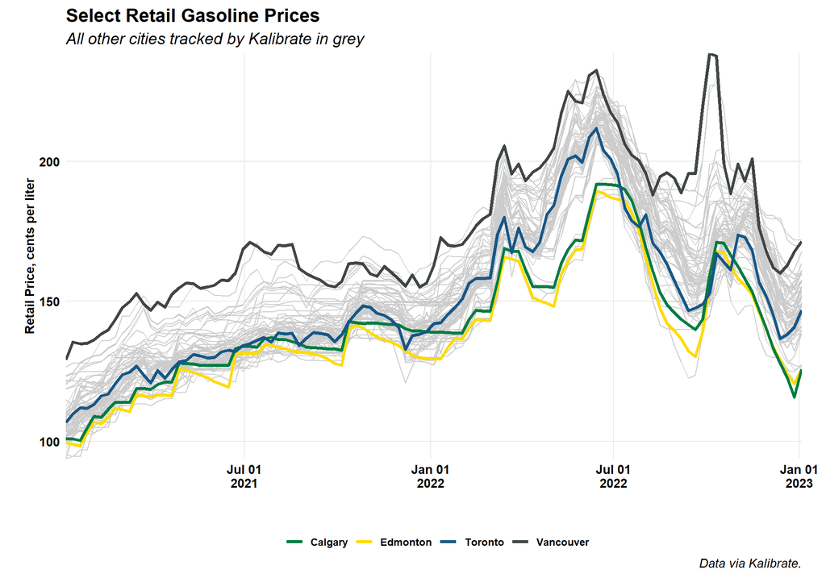

### Gasoline Prices in BTC

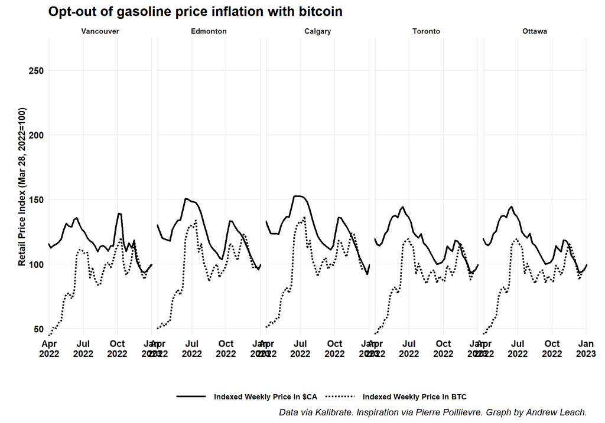

### Historic Diesel Prices

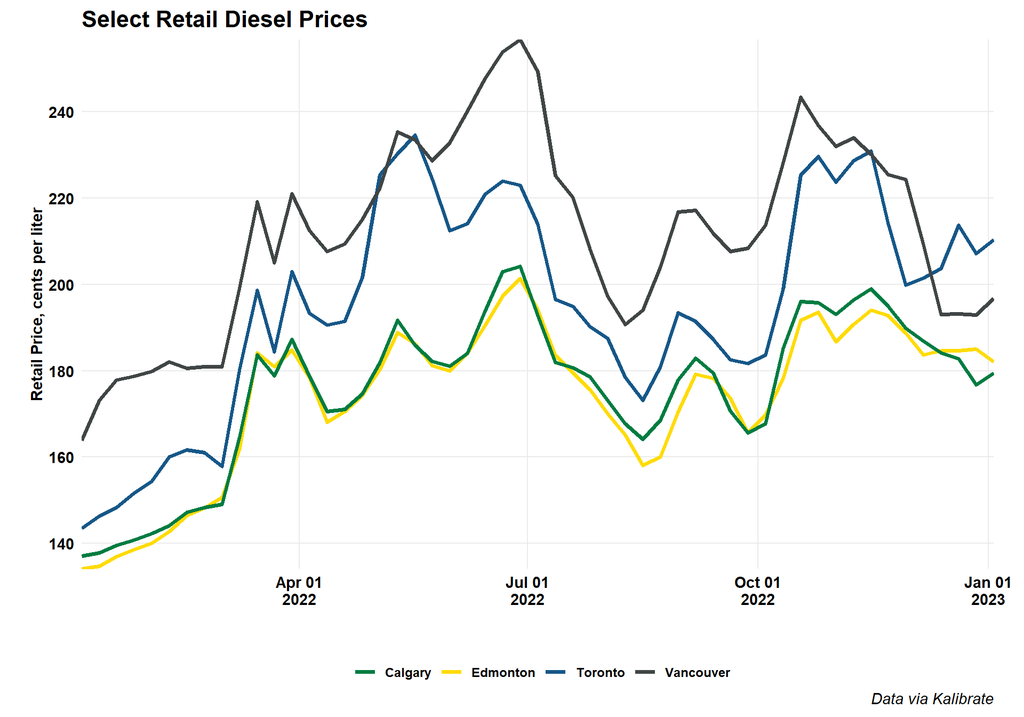